# FIT5197 2018 S1 Assignment 2

Nikhil Taralkar, 28980433

17 May 2018

## Task A

Build a linear regression model using the specific “auto mpg train.csv” provided with the assignment to predict mpg (mile per gallon). The second file “auto mpg test.csv”will be used for evaluation.

A.1: There are some missing values listed as “?”. Describe your strategy for treating missing values and update (edit by hand) the file accordingly.

I have replaced “?” values with mean value of horsepower.

```r
library(Metrics)
library(caret)
mpg_data <- read.csv('auto_mpg_train.csv')
head(mpg_data)
```

```
##   mpg cylinders displacement horsepower weight acceleration model.year
## 1  18         8          307        130   3504         12.0         70
## 2  15         8          350        165   3693         11.5         70
## 3  18         8          318        150   3436         11.0         70
## 4  16         8          304        150   3433         12.0         70
## 5  17         8          302        140   3449         10.5         70
## 6  15         8          429        198   4341         10.0         70
##   origin                  car.name
## 1      1 chevrolet chevelle malibu
## 2      1         buick skylark 320
## 3      1        plymouth satellite
## 4      1             amc rebel sst
## 5      1               ford torino
## 6      1          ford galaxie 500
```

```r
# creating dataframe
df <- data.frame(mpg_data)
```

A.2: Pair plot mpg vs. the other variables to visualize the relationships and discuss what you see.

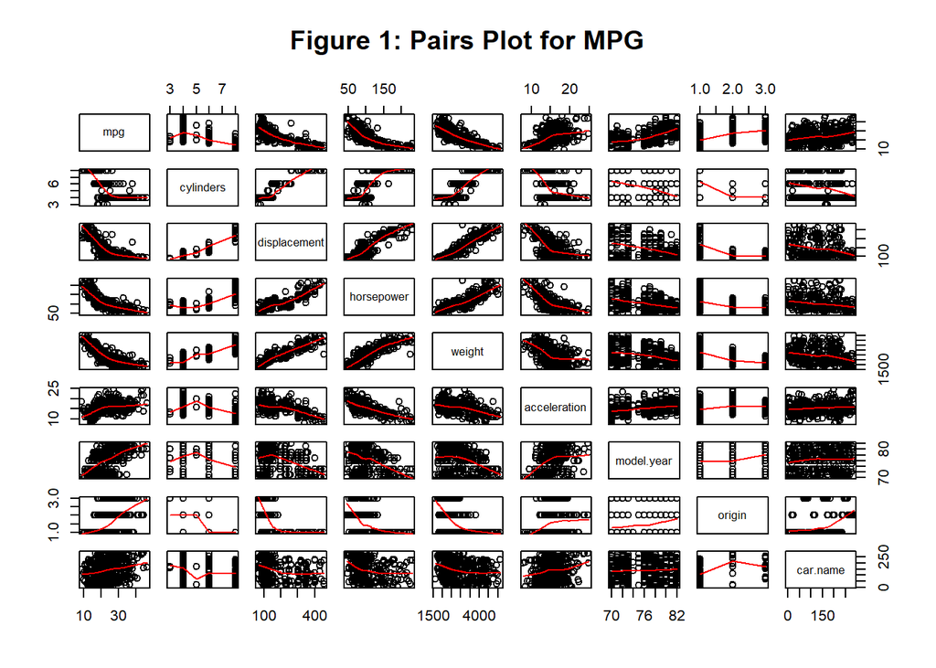

```r
# pair plot for auto mpg train dataset

pairs(df, panel = panel.smooth, main="Figure 1: Pairs Plot for MPG")
```

A.3: Based on your pair plots, propose an initial set of variables to use for a multiple linear regression model to predict mpg.

```r
# correlation between different columns in mpg train dataset
cor(df[,1:8])
```

```
##                     mpg  cylinders displacement horsepower     weight
## mpg           1.0000000 -0.7717897   -0.7991855 -0.7852616 -0.8306991
## cylinders    -0.7717897  1.0000000    0.9502605  0.8393205  0.8959469
## displacement -0.7991855  0.9502605    1.0000000  0.8975662  0.9327988
## horsepower   -0.7852616  0.8393205    0.8975662  1.0000000  0.8678581
## weight       -0.8306991  0.8959469    0.9327988  0.8678581  1.0000000
## acceleration  0.4581737 -0.5277690   -0.5746634 -0.6987341 -0.4534332
## model.year    0.5981966 -0.3739750   -0.3981105 -0.4446407 -0.3317539
## origin        0.5465047 -0.5494493   -0.5962623 -0.4516817 -0.5665474
##              acceleration model.year     origin
## mpg             0.4581737  0.5981966  0.5465047
## cylinders      -0.5277690 -0.3739750 -0.5494493
## displacement   -0.5746634 -0.3981105 -0.5962623
## horsepower     -0.6987341 -0.4446407 -0.4516817
## weight         -0.4534332 -0.3317539 -0.5665474
## acceleration    1.0000000  0.3186810  0.2224061
## model.year      0.3186810  1.0000000  0.1955691
## origin          0.2224061  0.1955691  1.0000000
```

```r
#Initial set of variables used for multiple Linear regression model to predict mpg

model <- lm(formula = mpg ~ cylinders  + weight + displacement + horsepower, data=mpg_data)
```

A.4: With variables of your choice build the model using the lm() routine in R, and then print the summary of the model to get the R diagnostics. Briefly explain the statistics in the summary, e.g. R2 value, t-value, standard error, p-value (ignoring the F-statistics line). What does this imply about the predictors for your model?

```r
model <- lm(formula = mpg ~ cylinders  + weight + displacement + horsepower, data=mpg_data)
summary(model)
```

```
##
## Call:
## lm(formula = mpg ~ cylinders + weight + displacement + horsepower,
##     data = mpg_data)
##
## Residuals:
##      Min       1Q   Median       3Q      Max
## -11.7388  -2.8605  -0.4091   2.4691  15.8292
##
## Coefficients:
##                Estimate Std. Error t value Pr(>|t|)
## (Intercept)  47.4852274  1.6675139  28.477  < 2e-16 ***
## cylinders    -0.4971540  0.4406348  -1.128 0.259995
## weight       -0.0055864  0.0007913  -7.060 9.31e-12 ***
## displacement  0.0065369  0.0097270   0.672 0.502015
## horsepower   -0.0538553  0.0138177  -3.898 0.000117 ***
## ---
## Signif. codes:  0 '***' 0.001 '**' 0.01 '*' 0.05 '.' 0.1 ' ' 1
##
## Residual standard error: 4.349 on 343 degrees of freedom
## Multiple R-squared:  0.7079, Adjusted R-squared:  0.7045
## F-statistic: 207.8 on 4 and 343 DF,  p-value: < 2.2e-16
```

A.5: Test the fitted model using the “auto mpg test.csv”, and calculate the MSE on the test set, reporting it. Note the test set has no missing values.

```r
auto_data <- read.csv('auto_mpg_test.csv')

# predicting values for mpg
model_prediction <- predict(model, auto_data)
model_prediction
```

```
##        1        2        3        4        5        6        7        8
## 24.42709 22.11466 31.51118 28.29334 32.20345 28.17192 19.62869 19.97481
##        9       10       11       12       13       14       15       16
## 20.13452 14.80898 11.46696 12.60970 12.03252 13.63547 29.27094 31.43855
##       17       18       19       20       21       22       23       24
## 29.08118 33.98091 31.56438 30.17462 30.26958 29.66862 27.15244 27.83689
##       25       26       27       28       29       30       31       32
## 31.23186 22.62273 21.15825 23.08631 24.61699 10.88988 13.18313 12.38066
##       33       34       35       36       37       38       39       40
## 11.81584 18.26205 18.71139 19.42734 19.71220 23.11107 21.30268 20.83140
##       41       42       43       44       45       46       47       48
## 29.96340 27.19919 24.35447 27.73103 26.10791 29.84257 26.83307 23.72623
##       49       50
## 31.49414 23.23385
```

Calculating MSE

```r
#importing library
library(Metrics)

# calculating MSE value
mse(model_prediction, auto_data$mpg)
```

```
## [1] 14.75972
```

A.6: Can you improve your model with different predictors? Try out some different ratios or products of the better predictor variables. How will you evaluate the different alternative predictors on your existing model (not using the test set)? Evaluate them and suggest which single predictor you would like to add (or none, if it looks like none would improve it). If you suggest adding a single predictor, then add it and repeat step A.5 to evalute it on the test set.

```r
model1 <- lm(formula = mpg ~ cylinders  + weight + displacement + horsepower + model.year, data=mpg_data)
summary(model1)
```

```
##
## Call:
## lm(formula = mpg ~ cylinders + weight + displacement + horsepower +
##     model.year, data = mpg_data)
##
## Residuals:
##    Min     1Q Median     3Q    Max
## -8.826 -2.373 -0.233  2.081 14.275
##
## Coefficients:
##                Estimate Std. Error t value Pr(>|t|)
## (Intercept)  -1.047e+01  4.516e+00  -2.320    0.021 *
## cylinders    -3.778e-01  3.570e-01  -1.058    0.291
## weight       -7.074e-03  6.503e-04 -10.878   <2e-16 ***
## displacement  1.377e-02  7.896e-03   1.744    0.082 .
## horsepower   -1.558e-02  1.155e-02  -1.349    0.178
## model.year    7.383e-01  5.489e-02  13.451   <2e-16 ***
## ---
## Signif. codes:  0 '***' 0.001 '**' 0.01 '*' 0.05 '.' 0.1 ' ' 1
##
## Residual standard error: 3.522 on 342 degrees of freedom
## Multiple R-squared:  0.809,  Adjusted R-squared:  0.8062
## F-statistic: 289.7 on 5 and 342 DF,  p-value: < 2.2e-16
```

```r
model1_pred <- predict(model1, auto_data)

mse(model1_pred, auto_data$mpg)
```

```
## [1] 8.662696
```

```r
model2 <- lm(formula = mpg ~ cylinders  + origin + displacement + weight + model.year, data=mpg_data)
summary(model2)
```

```
##
## Call:
## lm(formula = mpg ~ cylinders + origin + displacement + weight +
##     model.year, data = mpg_data)
##
## Residuals:
##      Min       1Q   Median       3Q      Max
## -10.1487  -2.2280   0.0382   1.8993  13.1399
##
## Coefficients:
##                Estimate Std. Error t value Pr(>|t|)
## (Intercept)  -1.621e+01  4.285e+00  -3.782 0.000183 ***
## cylinders    -4.269e-01  3.471e-01  -1.230 0.219679
## origin        1.225e+00  2.873e-01   4.265 2.59e-05 ***
## displacement  1.617e-02  7.232e-03   2.236 0.026010 *
## weight       -7.188e-03  6.179e-04 -11.633  < 2e-16 ***
## model.year    7.684e-01  5.205e-02  14.764  < 2e-16 ***
## ---
## Signif. codes:  0 '***' 0.001 '**' 0.01 '*' 0.05 '.' 0.1 ' ' 1
##
## Residual standard error: 3.441 on 342 degrees of freedom
## Multiple R-squared:  0.8177, Adjusted R-squared:  0.815
## F-statistic: 306.7 on 5 and 342 DF,  p-value: < 2.2e-16
```

```r
model2_pred <- predict(model2, auto_data)

mse(model2_pred, auto_data$mpg)
```

```
## [1] 7.207671
```

```r
#final best predictor
model3 <- lm(formula = mpg ~ origin + weight + model.year, data=mpg_data)
summary(model3)
```

```
##
## Call:
## lm(formula = mpg ~ origin + weight + model.year, data = mpg_data)
##
## Residuals:
##      Min       1Q   Median       3Q      Max
## -10.1389  -2.1770  -0.0552   1.7956  13.1857
##
## Coefficients:
##               Estimate Std. Error t value Pr(>|t|)
## (Intercept) -1.602e+01  4.216e+00  -3.801 0.000170 ***
## origin       1.070e+00  2.799e-01   3.825 0.000155 ***
## weight      -6.195e-03  2.791e-04 -22.200  < 2e-16 ***
## model.year   7.412e-01  5.041e-02  14.704  < 2e-16 ***
## ---
## Signif. codes:  0 '***' 0.001 '**' 0.01 '*' 0.05 '.' 0.1 ' ' 1
##
## Residual standard error: 3.457 on 344 degrees of freedom
## Multiple R-squared:  0.8149, Adjusted R-squared:  0.8133
## F-statistic: 504.8 on 3 and 344 DF,  p-value: < 2.2e-16
```

```r
model3_pred <- predict(model3, auto_data)

mse(model3_pred, auto_data$mpg)
```

```
## [1] 6.530443
```

## Task B: Logistic Regression

Build a logistic regression model using the specific “adult income train.csv” provided with the Assignment to predict the income variable. The second file “adult income test.csv”will be used for evaluation.

### Task B.1

B.1: There are some missing values listed as “?”. Describe your strategy for treating missing values, but note sometimes it is OK to leave missing value as a separate categorical value (we call this “missing informative”). Note there are too many to edit by hand, so if you wish to modify them, identify them with a Boolean test like data$workclass[id]==’?’ and modify the values in a loop.

```r
income_data_train <- read.csv('adult_income_train.csv', stringsAsFactors = FALSE)
#income_data_train
# Replacing "?" values in the dataset with 'Non-specified'

income_data_train$occupation[which (income_data_train$occupation == '?')] <- 'Non-specified'
income_data_train$workclass[which (income_data_train$workclass == '?')] <- 'Non-specified'
income_data_train$native_country[which (income_data_train$native_country == '?')] <- 'Non-specified'

income_data_train$occupation = as.factor(income_data_train$occupation)
income_data_train$workclass = as.factor(income_data_train$workclass)
income_data_train$native_country = as.factor(income_data_train$native_country)
income_data_train$income = as.factor(income_data_train$income)

#glm - logistic regression
logistic_model <- glm(income ~ .,family = binomial, data = income_data_train)
summary(logistic_model)
```

```
##
## Call:
## glm(formula = income ~ ., family = binomial, data = income_data_train)
##
## Deviance Residuals:
##     Min       1Q   Median       3Q      Max
## -5.1131  -0.5027  -0.1823  -0.0336   3.8667
##
## Coefficients: (2 not defined because of singularities)
##                                            Estimate Std. Error z value
## (Intercept)                              -6.700e+00  6.587e-01 -10.171
## age                                       2.493e-02  1.421e-03  17.547
## workclassLocal-gov                       -6.918e-01  9.684e-02  -7.144
## workclassNever-worked                    -9.352e+00  8.524e+01  -0.110
## workclassNon-specified                   -1.294e+00  1.191e-01 -10.858
## workclassPrivate                         -5.237e-01  8.067e-02  -6.491
## workclassSelf-emp-inc                    -3.686e-01  1.061e-01  -3.474
## workclassSelf-emp-not-inc                -1.063e+00  9.446e-02 -11.257
## workclassState-gov                       -8.881e-01  1.081e-01  -8.213
## workclassWithout-pay                     -1.402e+00  7.893e-01  -1.776
## fnlwgt                                    7.803e-07  1.473e-07   5.298
## education11th                             4.803e-02  1.834e-01   0.262
## education12th                             4.517e-01  2.274e-01   1.987
## education1st-4th                         -6.381e-01  4.437e-01  -1.438
## education5th-6th                         -3.744e-01  2.842e-01  -1.317
## education7th-8th                         -4.565e-01  2.001e-01  -2.281
## education9th                             -1.979e-01  2.244e-01  -0.882
## educationAssoc-acdm                       1.370e+00  1.525e-01   8.985
## educationAssoc-voc                        1.297e+00  1.473e-01   8.808
## educationBachelors                        1.930e+00  1.368e-01  14.113
## educationDoctorate                        2.871e+00  1.849e-01  15.524
## educationHS-grad                          8.032e-01  1.333e-01   6.027
## educationMasters                          2.265e+00  1.454e-01  15.578
## educationPreschool                       -5.110e+00  3.713e+00  -1.376
## educationProf-school                      2.782e+00  1.739e-01  16.001
## educationSome-college                     1.168e+00  1.352e-01   8.642
## educational_num                                  NA         NA      NA
## marital_statusMarried-AF-spouse           2.484e+00  4.762e-01   5.216
## marital_statusMarried-civ-spouse          2.324e+00  2.318e-01  10.028
## marital_statusMarried-spouse-absent       1.221e-01  1.898e-01   0.643
```

[output cut: 168 more lines]

```
## native_countryThailand                   0.040130 *
## native_countryTrinadad&Tobago            0.029784 *
## native_countryUnited-States              0.170587
## native_countryVietnam                    0.007915 **
## native_countryYugoslavia                 0.806358
## ---
## Signif. codes:  0 '***' 0.001 '**' 0.01 '*' 0.05 '.' 0.1 ' ' 1
##
## (Dispersion parameter for binomial family taken to be 1)
##
##     Null deviance: 48173  on 43841  degrees of freedom
## Residual deviance: 27615  on 43743  degrees of freedom
## AIC: 27813
##
## Number of Fisher Scoring iterations: 11
```

```r
# reading test csv file
income_test_data <- read.csv('adult_income_test.csv')
income_test_data$income = as.factor(income_test_data$income)

# prediction for income
prediction_value <- predict(logistic_model, income_test_data, type="response")
prediction_new <- ifelse(prediction_value > 0.5, 1, 0) # if predicted values > 0.5 assign 1, else 0
prediction_new <- factor(prediction_new) #setting factors level

# Assigning values 0 and 1 for income categorical value
income_test_data$income <- ifelse(income_test_data$income == '>50K', 1, 0)
income_test_data$income <- factor(income_test_data$income, level = c(0, 1))

# confusion matrix for predicted and actual data
#c = confusionMatrix(income_test_data$income, prediction_new)
# confusion Matrix
conf <- as.matrix(table(income_test_data$income, prediction_new))
conf
```

```
##    prediction_new
##        0    1
##   0 3507  264
##   1  493  736
```

```r
confusionMatrix(income_test_data$income, prediction_new)
```

```
## Confusion Matrix and Statistics
##
##           Reference
## Prediction    0    1
##          0 3507  264
##          1  493  736
##
##                Accuracy : 0.8486
##                  95% CI : (0.8384, 0.8584)
##     No Information Rate : 0.8
##     P-Value [Acc > NIR] : < 2.2e-16
##
##                   Kappa : 0.5643
##  Mcnemar's Test P-Value : < 2.2e-16
##
##             Sensitivity : 0.8768
##             Specificity : 0.7360
##          Pos Pred Value : 0.9300
##          Neg Pred Value : 0.5989
##              Prevalence : 0.8000
##          Detection Rate : 0.7014
##    Detection Prevalence : 0.7542
##       Balanced Accuracy : 0.8064
##
##        'Positive' Class : 0
##
```

```r
# finding Accuracy
N <- nrow(income_test_data) #Number of Observations
diag <- diag(conf)  #TN and TP
Accuracy <- sum(diag)/N #Accuracy = (TP + TN)/N
round(Accuracy*100,2)
```

```
## [1] 84.86
```

```r
#Distribution of instances over the actual and predicted classes:

rowsums = apply(conf, 1, sum) #Number of observations per class
colsums = apply(conf, 2, sum) #Number of predictions per class
Actual.Dist = rowsums / N #Distribution of observations over the actual classes
Predicted.Dist= colsums / N #Distribution of observations over the predicted classes
round(data.frame(Actual.Dist,Predicted.Dist)*100,2)
```

```
##   Actual.Dist Predicted.Dist
## 0       75.42             80
## 1       24.58             20
```